# INN_Learner_Notebook_Full_code

Bank Churn Prediction

## Problem Statement

### Context

Businesses like banks which provide service have to worry about problem of 'Customer Churn' i.e. customers leaving and joining another service provider. It is important to understand which aspects of the service influence a customer's decision in this regard. Management can concentrate efforts on improvement of service, keeping in mind these priorities.

### Objective

You as a Data scientist with the bank need to build a neural network based classifier that can determine whether a customer will leave the bank or not in the next 6 months.

### Data Dictionary

- CustomerId: Unique ID which is assigned to each customer
- Surname: Last name of the customer
- CreditScore: It defines the credit history of the customer.
- Geography: A customer’s location
- Gender: It defines the Gender of the customer
- Age: Age of the customer
- Tenure: Number of years for which the customer has been with the bank
- NumOfProducts: refers to the number of products that a customer has purchased through the bank.
- Balance: Account balance
- HasCrCard: It is a categorical variable which decides whether the customer has credit card or not.
- EstimatedSalary: Estimated salary
- isActiveMember: Is is a categorical variable which decides whether the customer is active member of the bank or not ( Active member in the sense, using bank products regularly, making transactions etc )
- Exited : whether or not the customer left the bank within six month. It can take two values ** 0=No ( Customer did not leave the bank ) ** 1=Yes ( Customer left the bank )

```python
# Import drive to access the files on My Drive
from google.colab import drive
drive.mount('/content/drive/')
import pandas as pd
# Save an object to Google Drive
# Load the dataset into the `Churn` DataFrame
Churn = pd.read_csv('/content/drive/MyDrive/Churn.csv')
import pickle
with open('/content/Churn.csv', 'wb') as f:
    pickle.dump(Churn, f)
# Reloading the object
with open('/content/Churn.csv', 'rb') as f:
    df2 = pickle.load(f)
```

```python
import numpy as np
import pandas as pd

# Libraries to help with data visualization
import matplotlib.pyplot as plt
import seaborn as sns


# Library to split data
from sklearn.model_selection import train_test_split
# library to import to standardize the data
from sklearn.preprocessing import StandardScaler

# To oversample and undersample data
from imblearn.over_sampling import SMOTE
from imblearn.under_sampling import RandomUnderSampler

#To import different metrics
from sklearn import metrics
from sklearn.metrics import explained_variance_score, mean_squared_error, r2_score, mean_absolute_error

#Importing classback API
from keras import callbacks

# Importing tensorflow library
import tensorflow as tf

# importing different functions to build models
from tensorflow.keras.layers import Dense, Dropout,InputLayer
from tensorflow.keras.models import Sequential

# Importing Batch Normalization
from keras.layers import BatchNormalization

# Importing backend
from tensorflow.keras import backend

# Importing shffule
from random import shuffle
from keras.callbacks import ModelCheckpoint

# Importing optimizers
from tensorflow.keras.optimizers import Adam
from tensorflow.keras.optimizers import SGD

# Library to avoid the warnings
import warnings
warnings.filterwarnings("ignore")
```

```python
# Display 5 sample rows
Churn.sample(5)
```

|  | RowNumber | CustomerId | Surname | CreditScore | Geography | Gender | Age | Tenure | Balance | NumOfProducts | HasCrCard | IsActiveMember | EstimatedSalary | Exited |
| --- | --- | --- | --- | --- | --- | --- | --- | --- | --- | --- | --- | --- | --- | --- |
| 9953 | 9954 | 15655952 | Burke | 550 | France | Male | 47 | 2 | 0.00 | 2 | 1 | 1 | 97057.28 | 0 |
| 3850 | 3851 | 15775293 | Stephenson | 680 | France | Male | 34 | 3 | 143292.95 | 1 | 1 | 0 | 66526.01 | 0 |
| 4962 | 4963 | 15665088 | Gordon | 531 | France | Female | 42 | 2 | 0.00 | 2 | 0 | 1 | 90537.47 | 0 |
| 3886 | 3887 | 15720941 | Tien | 710 | Germany | Male | 34 | 8 | 147833.30 | 2 | 0 | 1 | 1561.58 | 0 |
| 5437 | 5438 | 15733476 | Gonzalez | 543 | Germany | Male | 30 | 6 | 73481.05 | 1 | 1 | 1 | 176692.65 | 0 |

```python
#create a copy of the data
df = Churn.copy()
```

```python
#drop the first 2 columns
df.drop(['RowNumber','CustomerId','Surname'], axis=1, inplace=True)
#display the data frane columns to confirm the drop command wss successful
df.columns
```

```
Index(['CreditScore', 'Geography', 'Gender', 'Age', 'Tenure', 'Balance',
       'NumOfProducts', 'HasCrCard', 'IsActiveMember', 'EstimatedSalary',
       'Exited'],
      dtype='object')
```

It is observed that the first two columns 'RowNumber' and 'CustomerId' are unique for evry customer, hence they do not count as good predictors for our classification problem. The Surname is a variable that is common between customers just by chance and is not considered a valuable predictor as well. Therefore, those three columns need to be dropped.

```python
#check if the dataset has null values
df.isnull().sum()
```

|  | 0 |
| --- | --- |
| CreditScore | 0 |
| Geography | 0 |
| Gender | 0 |
| Age | 0 |
| Tenure | 0 |
| Balance | 0 |
| NumOfProducts | 0 |
| HasCrCard | 0 |
| IsActiveMember | 0 |
| EstimatedSalary | 0 |
| Exited | 0 |

**dtype:** int64

```python
#check if the dataset has duplicated values
df.duplicated().sum()
```

```
0
```

```python
#display the data types of all variables
df.dtypes
```

|  | 0 |
| --- | --- |
| CreditScore | int64 |
| Geography | object |
| Gender | object |
| Age | int64 |
| Tenure | int64 |
| Balance | float64 |
| NumOfProducts | int64 |
| HasCrCard | int64 |
| IsActiveMember | int64 |
| EstimatedSalary | float64 |
| Exited | int64 |

**dtype:** object

```python
#Derive the 5 point summary of the data
df.describe(include='all')
```

|  | CreditScore | Geography | Gender | Age | Tenure | Balance | NumOfProducts | HasCrCard | IsActiveMember | EstimatedSalary | Exited |
| --- | --- | --- | --- | --- | --- | --- | --- | --- | --- | --- | --- |
| count | 10000.000000 | 10000 | 10000 | 10000.000000 | 10000.000000 | 10000.000000 | 10000.000000 | 10000.00000 | 10000.000000 | 10000.000000 | 10000.000000 |
| unique | NaN | 3 | 2 | NaN | NaN | NaN | NaN | NaN | NaN | NaN | NaN |
| top | NaN | France | Male | NaN | NaN | NaN | NaN | NaN | NaN | NaN | NaN |
| freq | NaN | 5014 | 5457 | NaN | NaN | NaN | NaN | NaN | NaN | NaN | NaN |
| mean | 650.528800 | NaN | NaN | 38.921800 | 5.012800 | 76485.889288 | 1.530200 | 0.70550 | 0.515100 | 100090.239881 | 0.203700 |
| std | 96.653299 | NaN | NaN | 10.487806 | 2.892174 | 62397.405202 | 0.581654 | 0.45584 | 0.499797 | 57510.492818 | 0.402769 |
| min | 350.000000 | NaN | NaN | 18.000000 | 0.000000 | 0.000000 | 1.000000 | 0.00000 | 0.000000 | 11.580000 | 0.000000 |
| 25% | 584.000000 | NaN | NaN | 32.000000 | 3.000000 | 0.000000 | 1.000000 | 0.00000 | 0.000000 | 51002.110000 | 0.000000 |
| 50% | 652.000000 | NaN | NaN | 37.000000 | 5.000000 | 97198.540000 | 1.000000 | 1.00000 | 1.000000 | 100193.915000 | 0.000000 |
| 75% | 718.000000 | NaN | NaN | 44.000000 | 7.000000 | 127644.240000 | 2.000000 | 1.00000 | 1.000000 | 149388.247500 | 0.000000 |
| max | 850.000000 | NaN | NaN | 92.000000 | 10.000000 | 250898.090000 | 4.000000 | 1.00000 | 1.000000 | 199992.480000 | 1.000000 |

These observations will be validated through Exploratory Data Analysis (EDA).

**Exploratory Data Analysis**

1. Univariate Analysis

EDA For the numerical variables We will create a function to plot the histogram and box plot for all variables (note that all variables are numerical)

```python
def histogram_boxplot(data, feature, figsize=(12, 7), kde=False, bins=None):
    """
    Boxplot and histogram combined

    data: dataframe
    feature: dataframe column
    figsize: size of figure (default (12,7))
    kde: whether to the show density curve (default False)
    bins: number of bins for histogram (default None)
    """
    f2, (ax_box2, ax_hist2) = plt.subplots(
        nrows=2,  # Number of rows of the subplot grid= 2
        sharex=True,  # x-axis will be shared among all subplots
        gridspec_kw={"height_ratios": (0.25, 0.75)},
        figsize=figsize,
    )  # creating the 2 subplots
    sns.boxplot(
        data=data, x=feature, ax=ax_box2, showmeans=True, color="violet"
    )  # boxplot will be created and a star will indicate the mean value of the column
    sns.histplot(
        data=data, x=feature, kde=kde, ax=ax_hist2, bins=bins, palette="winter"
    ) if bins else sns.histplot(
        data=data, x=feature, kde=kde, ax=ax_hist2, discrete=True
    )  # For histogram
    ax_hist2.axvline(
        data[feature].mean(), color="green", linestyle="--"
    )  # Add mean to the histogram
    ax_hist2.axvline(
        data[feature].median(), color="black", linestyle="-"
    )  # Add median to the histogram
```

[output not shown]

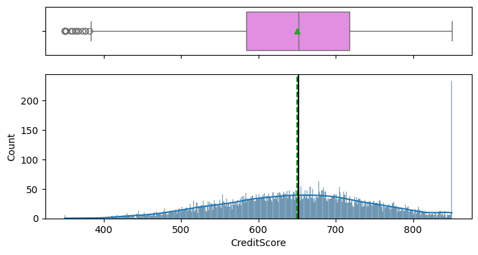

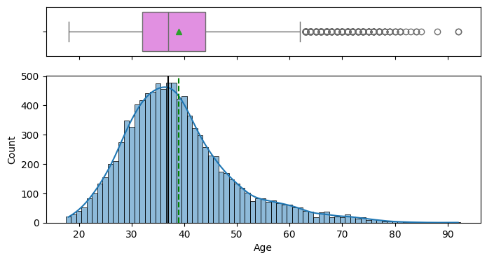

[figure not shown]

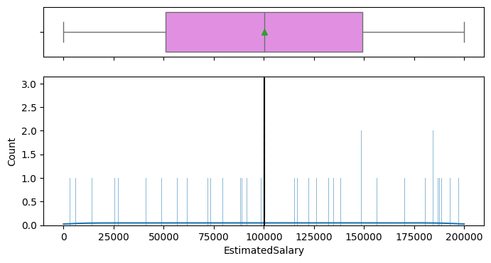

```python
# create a list of numerical columns
numerical = ['CreditScore', 'Age', 'Balance','EstimatedSalary']

# ploting the numerical variables
for i in numerical:
    histogram_boxplot(df, i, kde=True, figsize=(8, 4))
```

**Observations**

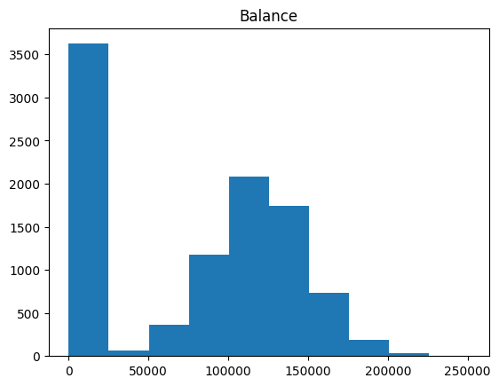

```python
#plotting the data on a logarithmic scale
plt.hist(df['Balance']);
plt.title('Balance');
```

The balance histogram is right skewed and shows a significant number of customers (approx. 3500) with 0 balance. The remaining customers show adopt an almost normally distributed balance values. This indicates there are two different customer clusters at least. It is interesting to study further how these cluster vary with respect to our target variable in the bivariate analysis.

Estinated Salary distribution on a logarithmic scale:

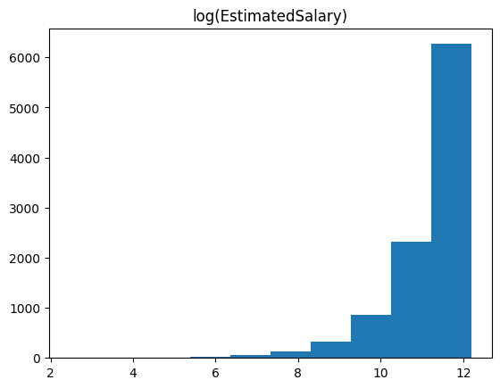

```python
#plotting the data on a logarithmic scale
plt.hist(np.log(df['EstimatedSalary']));
plt.title('log(EstimatedSalary)');
```

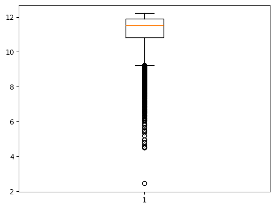

```python
plt.boxplot(np.log(df['EstimatedSalary']));
```

On a logarithmic scale, the Estimated Salary is heavily left skewed with a high number of outliers beyond the left skewer. The outliers still seem consistent with the reality situation as a number of customers can be of high age and retired with no income salary or non-working customers.

**EDA For the categorical variables**  
We will create a function to plot labelled barplots for all variables (note that all variables are categorical)

```python
# funtcion to plot labelled barplot
def labeled_barplot(data, feature, perc=False, n=None):
    """
    Barplot with percentage at the top

    data: dataframe
    feature: dataframe column
    perc: whether to display percentages instead of count (default is False)
    n: displays the top n category levels (default is None, i.e., display all levels)
    """

    total = len(data[feature])  # length of the column
    count = data[feature].nunique()
    if n is None:
        plt.figure(figsize=(count + 1, 5))
    else:
        plt.figure(figsize=(n + 1, 5))

    plt.xticks(rotation=90, fontsize=15)
    ax = sns.countplot(
        data=data,
        x=feature,
        palette="Paired",
        order=data[feature].value_counts().index[:n].sort_values(),
    )

    for p in ax.patches:
        if perc == True:
            label = "{:.1f}%".format(
                100 * p.get_height() / total
            )  # percentage of each class of the category
        else:
            label = p.get_height()  # count of each level of the category

        x = p.get_x() + p.get_width() / 2  # width of the plot
        y = p.get_height()  # height of the plot

        ax.annotate(
            label,
            (x, y),
            ha="center",
            va="center",
            size=12,
            xytext=(0, 5),
            textcoords="offset points",
        )  # annotate the percentage

    plt.show()  # show the plot
```

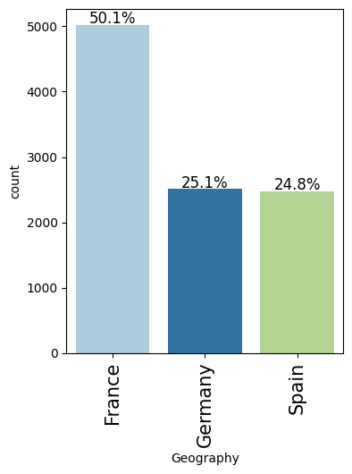

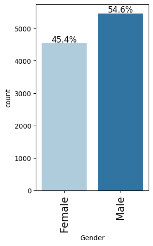

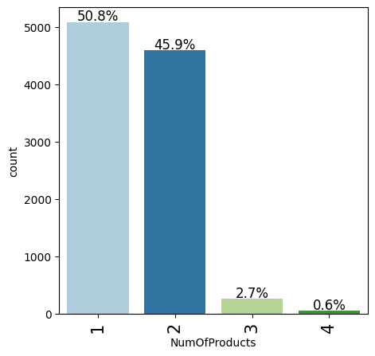

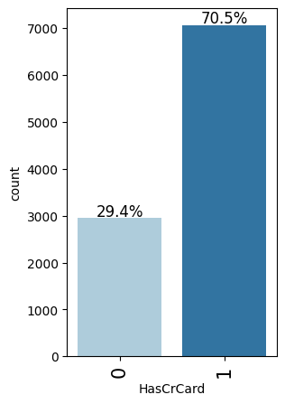

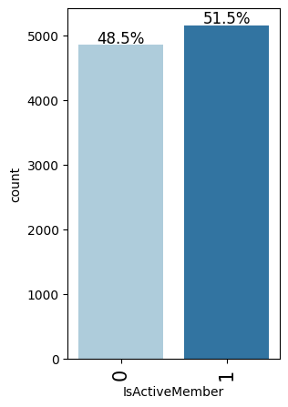

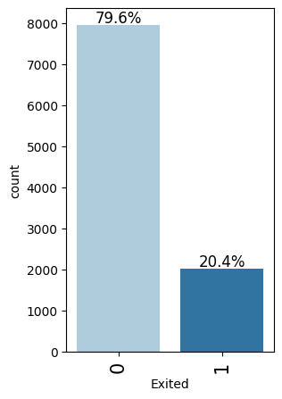

```python
# create a list of categorical columns
categorical = ['Geography', 'Gender', 'NumOfProducts', 'HasCrCard', 'IsActiveMember','Exited']
# ploting the categorical variables
for i in categorical:
    labeled_barplot(df, i, perc=True)
```

**Observations**

- Geography: 50% of customers are from France, 25% from Germany, and 25% from Spain.
- Gender: Approximately 55% of customers are male, with the remainder female.
- NumOfProducts: Half of the customers use only one product, around 46% use two products, and the remaining 3.3% use three to four products.
- HasCrCard: Most customers (70%) have credit cards.
- IsActiveMember: Nearly half of the customers are active members, with a slight majority being active.
- Exited: Around 20% of customers have exited, while 80% have not. This indicates an imbalance in the target

**2. Bivariate analysis**

- Use appropriate visualizations to identify the patterns and insights - Any other exploratory deep dive
- Start by plotting the pair plot and heatmap to observe if there are any correlations between variables and/or clear clusterring.

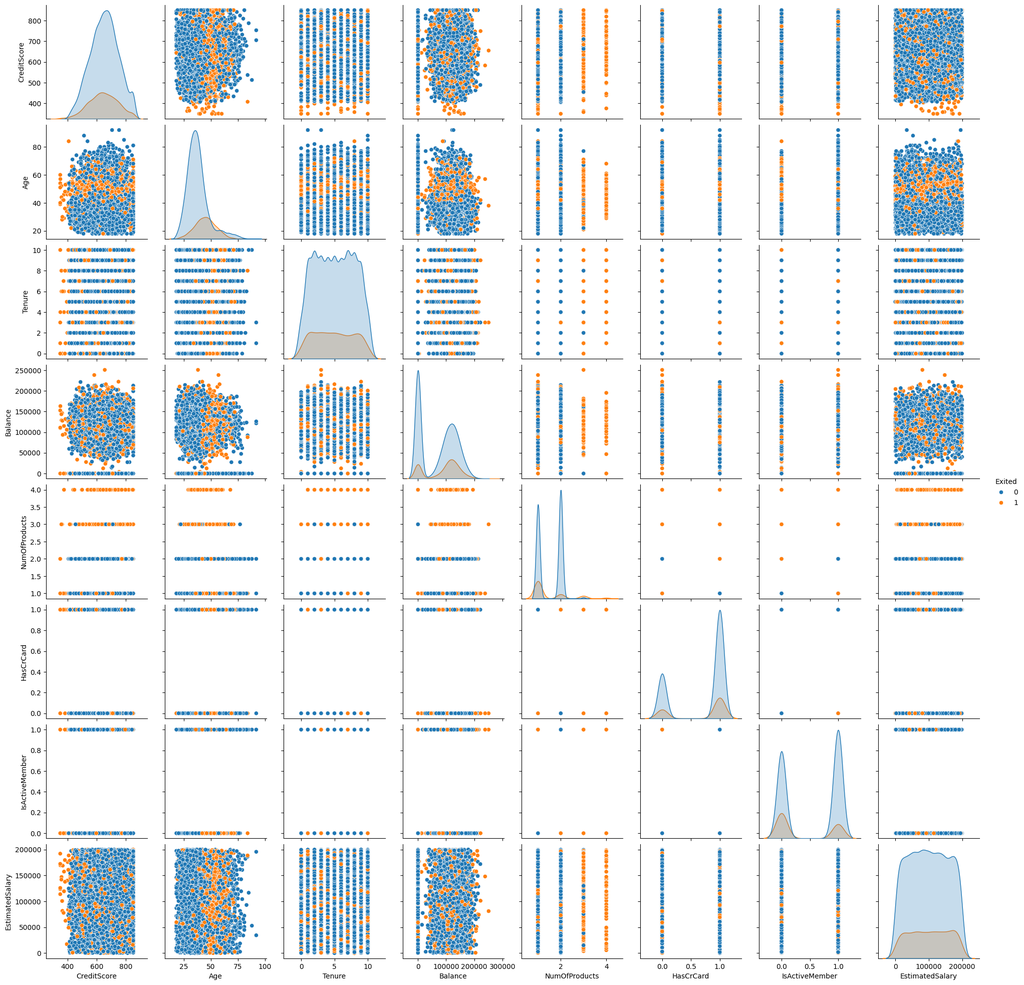

```python
plt.figure(figsize=(15,15))
sns.pairplot(df, hue="Exited",diag_kind='kde')
```

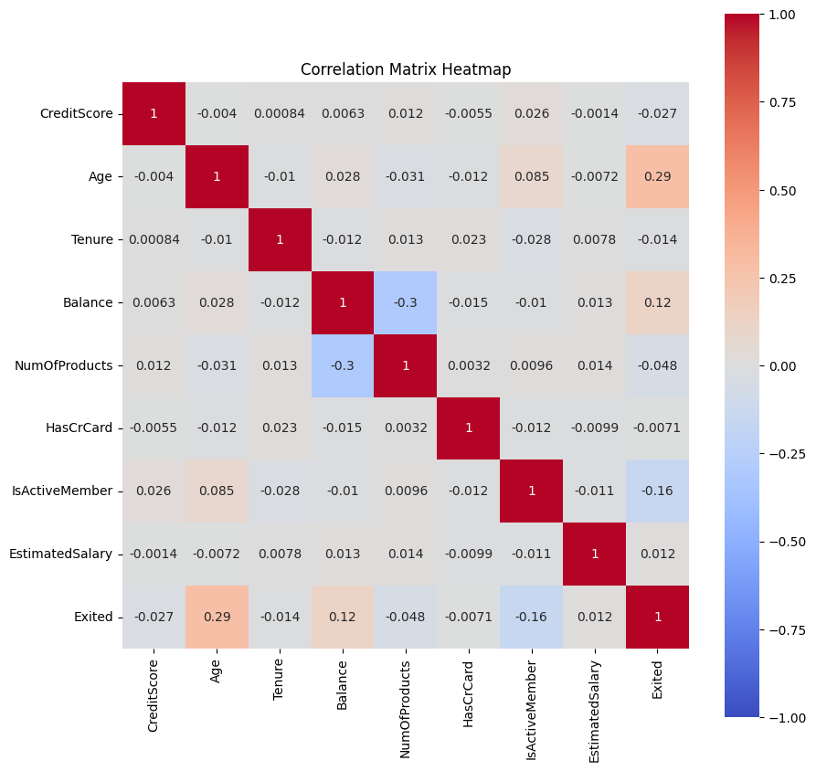

```python
# Select only numeric columns from the DataFrame for the correlation calculation
numeric_df = df.select_dtypes(include=['number'])

plt.figure(figsize=(10, 10))  # Set the figure size for better readability
sns.heatmap(numeric_df.corr(), vmax=1, vmin=-1, annot=True, cmap="coolwarm", square=True)
plt.title("Correlation Matrix Heatmap")
plt.show()
```

**Observations:**

- The pair plot and heat map reveal no notable correlations between the variables.
- The pair plot indicates distinct clustering patterns in certain variables: Balance (2 clusters), Num of Products (3-4 clusters), HasCrCards (2 clusters), and IsActiveMember (2 clusters).
- Both exited and non-exited customers are represented across all clusters. However, due to class imbalance, exited customers are significantly fewer than non-exited customers.

```python
### function to plot distributions wrt target


def distribution_plot_wrt_target(data, predictor, target):

    fig, axs = plt.subplots(2, 2, figsize=(12, 10))

    target_uniq = data[target].unique()

    axs[0, 0].set_title("Distribution of target for target=" + str(target_uniq[0]))
    sns.histplot(
        data=data[data[target] == target_uniq[0]],
        x=predictor,
        kde=False,
        ax=axs[0, 0],
        color="teal",
        stat="density",
    )

    axs[0, 1].set_title("Distribution of variable for target=" + str(target_uniq[1]))
    sns.histplot(
        data=data[data[target] == target_uniq[1]],
        x=predictor,
        kde=False,
        ax=axs[0, 1],
        color="orange",
        stat="density",
    )

    axs[1, 0].set_title("Boxplot w.r.t target")
    sns.boxplot(data=data, x=target, y=predictor, ax=axs[1, 0], palette="gist_rainbow")

    axs[1, 1].set_title("Boxplot (without outliers) w.r.t target")
    sns.boxplot(
        data=data,
        x=target,
        y=predictor,
        ax=axs[1, 1],

        showfliers=False,
        palette="gist_rainbow",
    )

    plt.tight_layout()
    plt.show()
```

**Observations:**

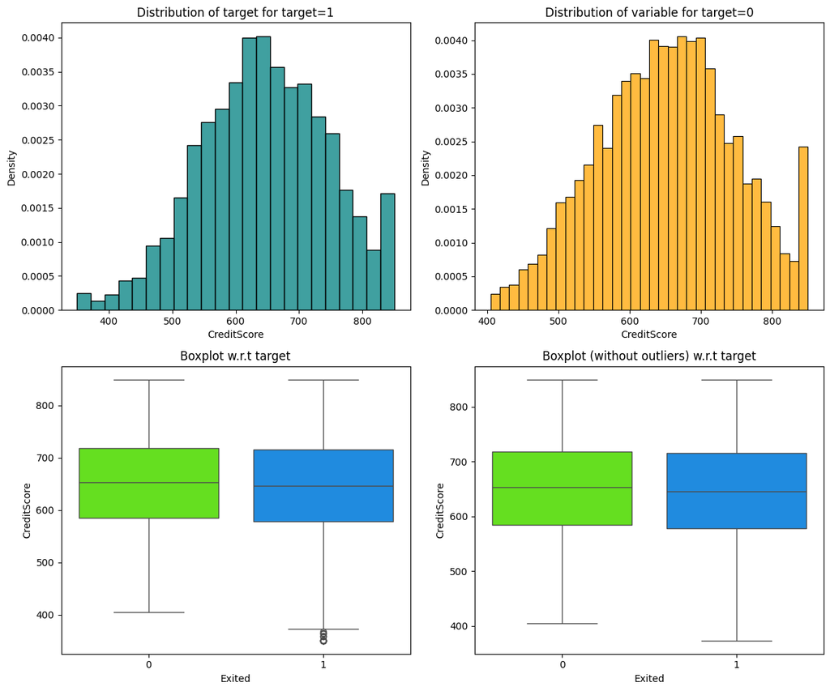

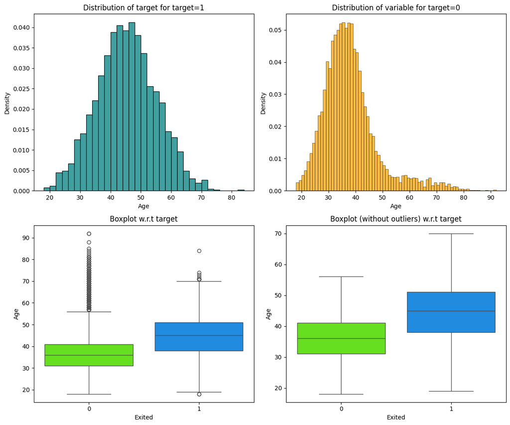

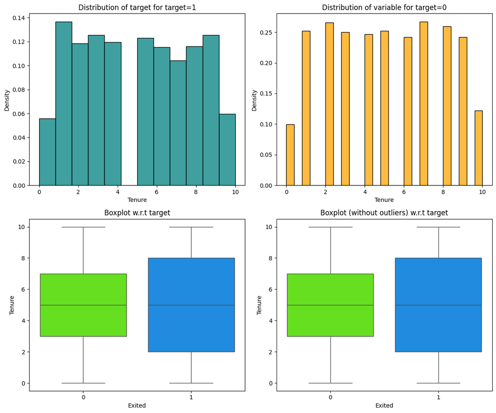

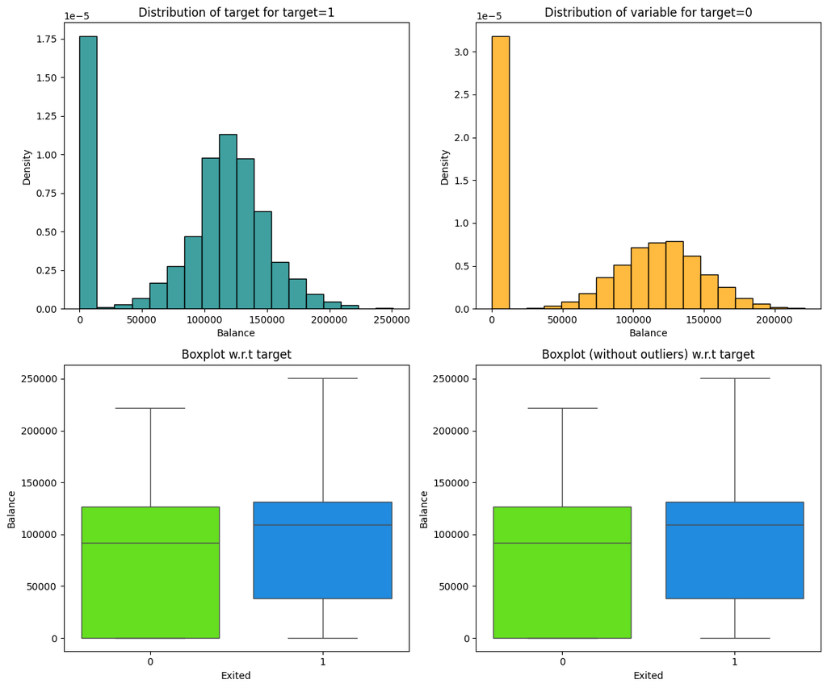

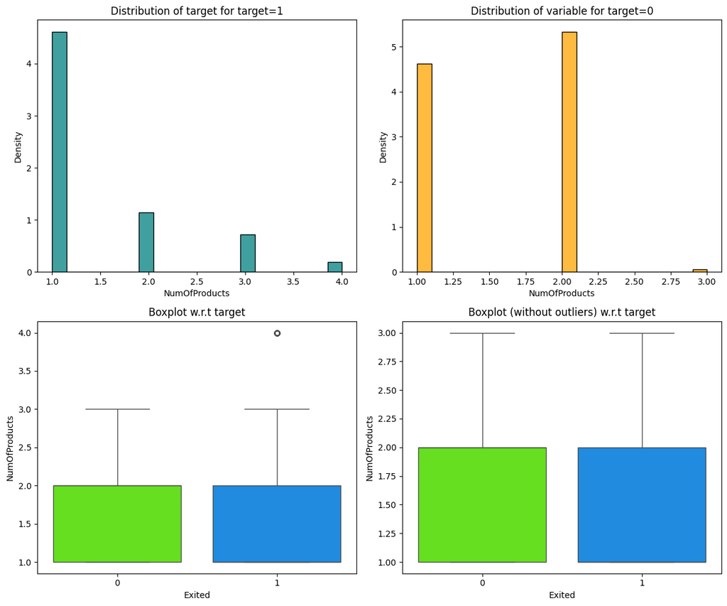

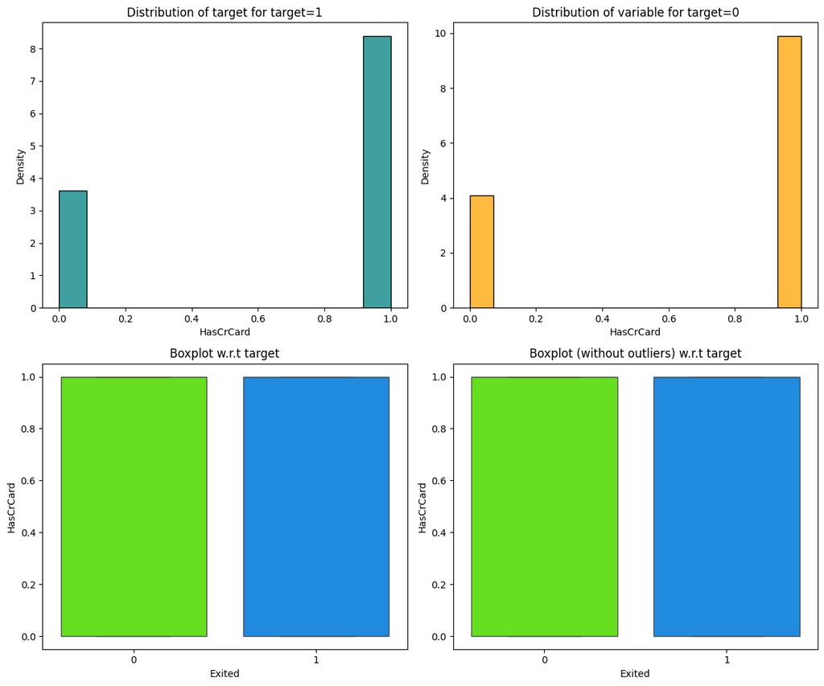

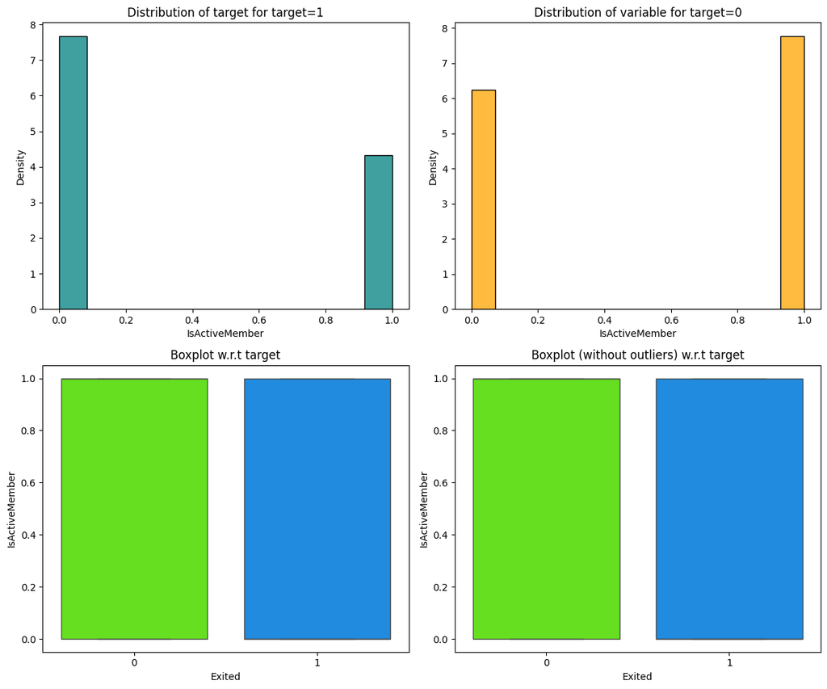

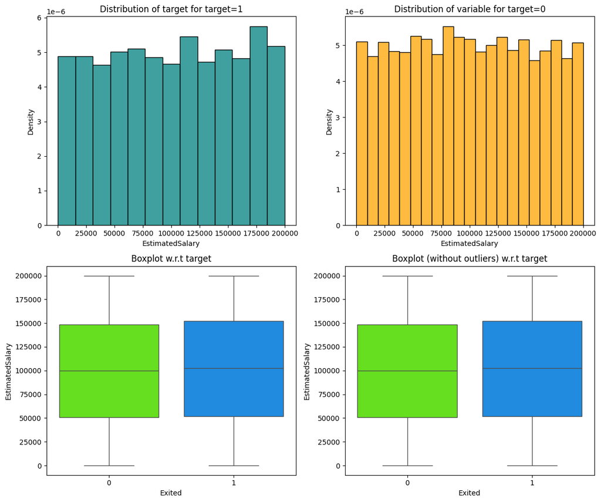

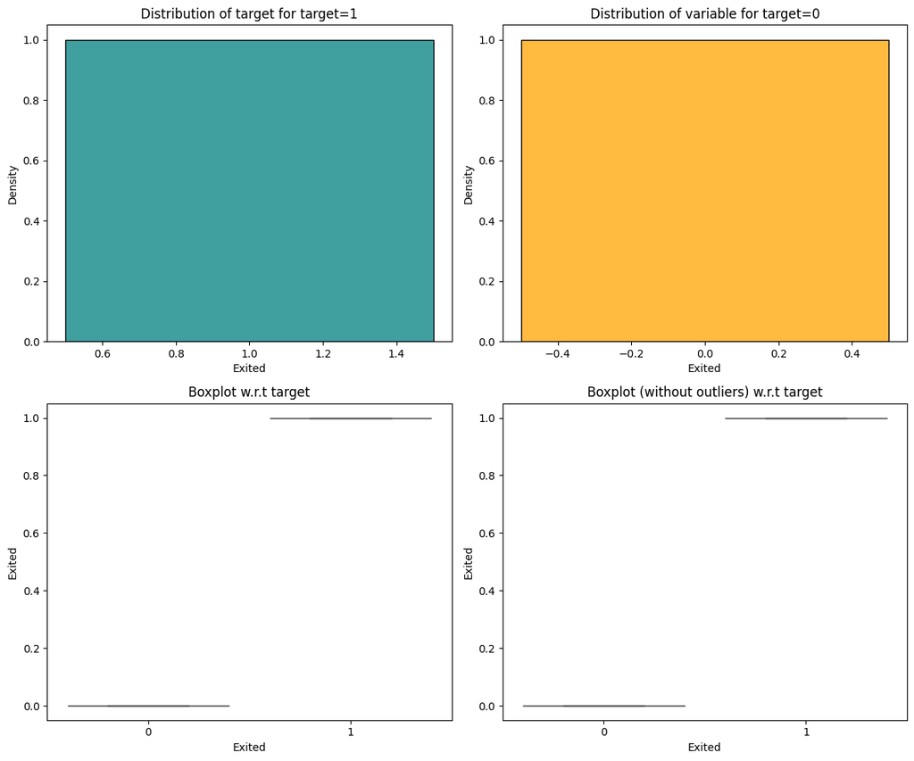

```python
# Define `numerical` as the list of numeric column names in `df`
numerical = df.select_dtypes(include=['number']).columns

# Example loop to call `distribution_plot_wrt_target` for each numeric column
for i in numerical:
    distribution_plot_wrt_target(df, i, 'Exited')
```

```python
# function to plot stacked bar chart


def stacked_barplot(data, predictor, target):
    """
    Print the category counts and plot a stacked bar chart

    data: dataframe
    predictor: independent variable
    target: target variable
    """
    count = data[predictor].nunique()
    sorter = data[target].value_counts().index[-1]
    tab1 = pd.crosstab(data[predictor], data[target], margins=True).sort_values(
        by=sorter, ascending=False
    )
    print(tab1)
    print("-" * 120)
    tab = pd.crosstab(data[predictor], data[target], normalize="index").sort_values(
        by=sorter, ascending=False
    )
    tab.plot(kind="bar", stacked=True, figsize=(count + 5, 6))
    plt.legend(
        loc="lower left", frameon=False,
    )
    plt.legend(loc="upper left", bbox_to_anchor=(1, 1))
    plt.show()
```

**Observations**

- Geography: The highest proportion of exited customers comes from Germany, while Spain and France show almost identical exit ratios. This variable is considered a reasonably good predictor.
- Gender: A greater proportion of exited customers are female, making Gender a fairly good predictor.
- NumOfProducts: All customers with 4 products, as well as a large proportion of those with 3 products, have exited. The lowest exit ratio is among customers with 2 products, indicating strong predictive power for this variable.
- HasCrCard: The exit ratio is nearly the same for customers with and without credit cards, making this a very poor predictor.
- IsActiveMember: A higher proportion of non-active customers have exited compared to active ones, making this a fairly good predictor.

```
Exited        0     1    All
Geography
All        7963  2037  10000
Germany    1695   814   2509
France     4204   810   5014
Spain      2064   413   2477
------------------------------------------------------------------------------------------------------------------------
```

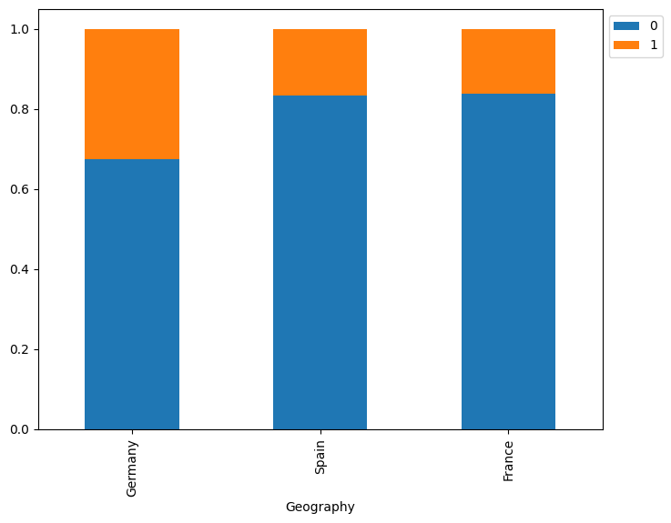

```
Exited     0     1    All
Gender
All     7963  2037  10000
Female  3404  1139   4543
Male    4559   898   5457
------------------------------------------------------------------------------------------------------------------------
```

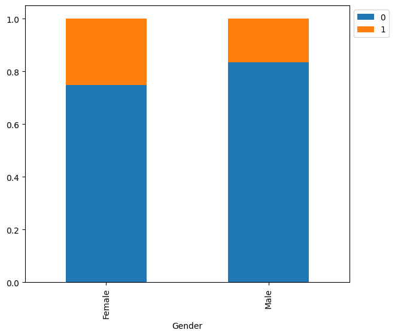

```
Exited            0     1    All
NumOfProducts
All            7963  2037  10000
1              3675  1409   5084
2              4242   348   4590
3                46   220    266
4                 0    60     60
------------------------------------------------------------------------------------------------------------------------
```

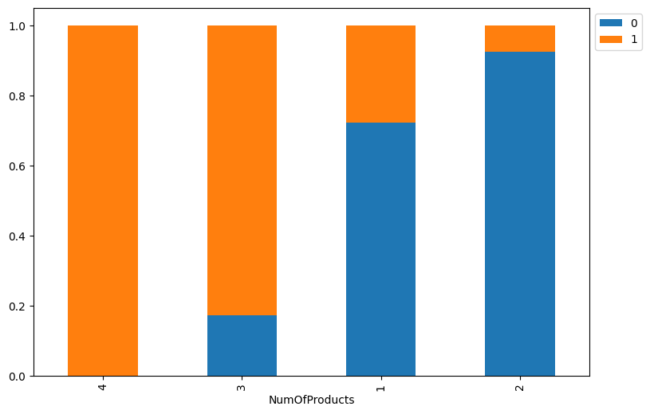

```
Exited        0     1    All
HasCrCard
All        7963  2037  10000
1          5631  1424   7055
0          2332   613   2945
------------------------------------------------------------------------------------------------------------------------
```

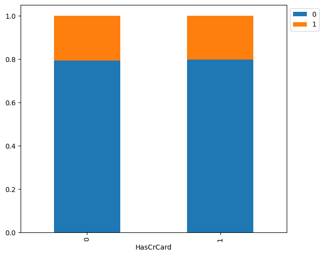

```
Exited             0     1    All
IsActiveMember
All             7963  2037  10000
0               3547  1302   4849
1               4416   735   5151
------------------------------------------------------------------------------------------------------------------------
```

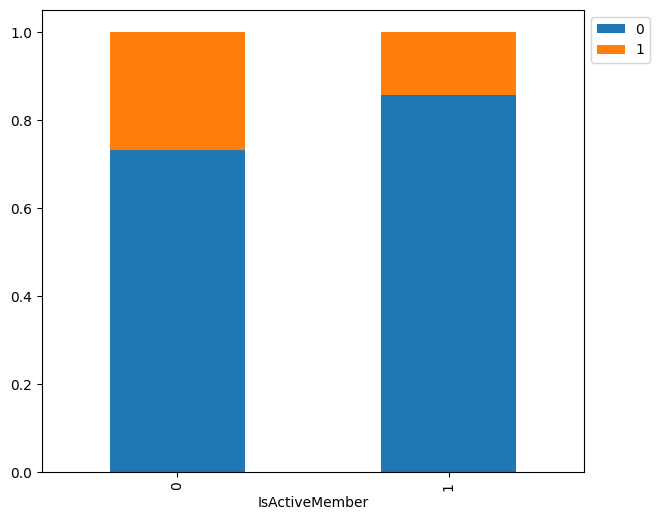

```python
categorical = ['Geography', 'Gender', 'NumOfProducts', 'HasCrCard', 'IsActiveMember']

# ploting the categorical variables
for i in categorical:
    stacked_barplot(df, i, 'Exited')
```

**EDA Insights**  
From the Univariate Analysis we conclude:

- All bank customers come are based in France, Germany or Spain and their Age vary from 18 to 92 years old.
- The majority of customers are Males, from France, have credit cards and have not exited the bank

**Data Pre-processing**  
Splitting the target variable and predictors

```python
X = df.drop('Exited',axis=1)
y = df['Exited']
```

Applying one-hot-encoding for the categorical features

```python
dummy_cat = ['Geography','Gender']
X = pd.get_dummies(X,columns=dummy_cat,drop_first= True)
X.head()
```

|  | CreditScore | Age | Tenure | Balance | NumOfProducts | HasCrCard | IsActiveMember | EstimatedSalary | Geography_Germany | Geography_Spain | Gender_Male |
| --- | --- | --- | --- | --- | --- | --- | --- | --- | --- | --- | --- |
| 0 | 619 | 42 | 2 | 0.00 | 1 | 1 | 1 | 101348.88 | False | False | False |
| 1 | 608 | 41 | 1 | 83807.86 | 1 | 0 | 1 | 112542.58 | False | True | False |
| 2 | 502 | 42 | 8 | 159660.80 | 3 | 1 | 0 | 113931.57 | False | False | False |
| 3 | 699 | 39 | 1 | 0.00 | 2 | 0 | 0 | 93826.63 | False | False | False |
| 4 | 850 | 43 | 2 | 125510.82 | 1 | 1 | 1 | 79084.10 | False | True | False |

3.Scaling the numerical data using zscore to unite the distribution of all variables to a mean of 0 and a std of 1.

```python
# to scale the data
from scipy.stats import zscore
X_Scaled = X.apply(zscore)
X_Scaled.head()
```

|  | CreditScore | Age | Tenure | Balance | NumOfProducts | HasCrCard | IsActiveMember | EstimatedSalary | Geography_Germany | Geography_Spain | Gender_Male |
| --- | --- | --- | --- | --- | --- | --- | --- | --- | --- | --- | --- |
| 0 | -0.326221 | 0.293517 | -1.041760 | -1.225848 | -0.911583 | 0.646092 | 0.970243 | 0.021886 | -0.578736 | -0.573809 | -1.095988 |
| 1 | -0.440036 | 0.198164 | -1.387538 | 0.117350 | -0.911583 | -1.547768 | 0.970243 | 0.216534 | -0.578736 | 1.742740 | -1.095988 |
| 2 | -1.536794 | 0.293517 | 1.032908 | 1.333053 | 2.527057 | 0.646092 | -1.030670 | 0.240687 | -0.578736 | -0.573809 | -1.095988 |
| 3 | 0.501521 | 0.007457 | -1.387538 | -1.225848 | 0.807737 | -1.547768 | -1.030670 | -0.108918 | -0.578736 | -0.573809 | -1.095988 |
| 4 | 2.063884 | 0.388871 | -1.041760 | 0.785728 | -0.911583 | 0.646092 | 0.970243 | -0.365276 | -0.578736 | 1.742740 | -1.095988 |

Split the data to test and train

```python
# Split the non-scaled data into train and test
X_train_ns, X_test_ns, y_train_ns, y_test_ns = train_test_split(X, y, test_size=0.2, random_state=1, stratify=y)
```

```python
# Split the scaled data into train and test
X_train, X_test, y_train, y_test = train_test_split(X_Scaled, y, test_size=0.2, random_state=1, stratify=y)
```

```python
#displaying the shape of train and test data sets to confirm the split was successful
print(f''' X_train shape: {X_train.shape}
 X_test shape: {X_test.shape}
 y_train shape: {y_train.shape}
 y_test shape: {y_test.shape}''')
```

```
 X_train shape: (8000, 11)
 X_test shape: (2000, 11)
 y_train shape: (8000,)
 y_test shape: (2000,)
```

4.Data Oversampling: To balance the target variable class ration we will prepare an oversampled train and test datasets using the SMOTE algorithm train data is zscore scaled

```python
print("Before UpSampling, counts of label 'Yes': {}".format(sum(y_train == 1)))
print("Before UpSampling, counts of label 'No': {} \n".format(sum(y_train == 0)))

sm = SMOTE(sampling_strategy=1, k_neighbors=5, random_state=1)

X_train_over, y_train_over = sm.fit_resample(X_train, y_train)

print("After UpSampling, counts of label 'Yes': {}".format(sum(y_train_over == 1)))
print("After UpSampling, counts of label 'No': {} \n".format(sum(y_train_over == 0)))


print("After UpSampling, the shape of X_train: {}".format(X_train_over.shape))
print("After UpSampling, the shape of y-train: {} \n".format(y_train_over.shape))
```

```
Before UpSampling, counts of label 'Yes': 1630
Before UpSampling, counts of label 'No': 6370

After UpSampling, counts of label 'Yes': 6370
After UpSampling, counts of label 'No': 6370

After UpSampling, the shape of X_train: (12740, 11)
After UpSampling, the shape of y-train: (12740,)
```

5.Data Undersampling: To balance the target variable class ration we will prepare an undersampled train and test datasets using the Random Under Sampler noting that the train data is zscore scaled

```python
#applting the random under sampler using sampling strategy 0.5
random_us = RandomUnderSampler(random_state=1, sampling_strategy = 0.5)
X_train_un, y_train_un = random_us.fit_resample(X_train, y_train)

print("After UpSampling, counts of label 'Yes': {}".format(sum(y_train_un == 1)))
print("After UpSampling, counts of label 'No': {} \n".format(sum(y_train_un == 0)))


print("After UpSampling, the shape of X_train: {}".format(X_train_un.shape))
print("After UpSampling, the shape of y-train: {} \n".format(y_train_un.shape))
```

```
After UpSampling, counts of label 'Yes': 1630
After UpSampling, counts of label 'No': 3260

After UpSampling, the shape of X_train: (4890, 11)
After UpSampling, the shape of y-train: (4890,)
```

The dataset now is ready for modeling noting that the over sampled and under sampled data will be utilized only if required to enhance the model performance.

**Model building**  
Our key performance metric is the Recall as we are aiming to reduce the False Negatives and hence, predict correctly the customers that are most likely to exit the bank and take early actions to avoid this from occuring. We will start by a very simple model using the rule of thumb parameters as initial parameters, observe the performance and start enhancing it.

```python
backend.clear_session()
#Fixing the seed for random number generators so that we can ensure we receive the same output everytime
np.random.seed(1)
import random
random.seed(1)
tf.random.set_seed(1)
```

**Choose the metric of choice with proper rationale - Train a Neural Network model with SGD as an optimizer:**

- Hidden layers = 2
- Activation function for hidden layers = Relu
- Output layer with 1 nodes
- Output Activation function = Sigmoid
- Output loss function = Cross Entropy (since this is a classification problem)
- Optimizer = SGD
- epochs = 20
- Data is scaled using zscore

```python
# Initializing the model
model_01 = Sequential()

# Adding the first layer with 64 neurons, ReLU as the activation function
model_01.add(Dense(64, activation='relu', input_dim=11))

# Adding the second hidden layer with 32 neurons, ReLU as the activation function
model_01.add(Dense(32, activation='relu'))

# Adding the output layer with one neuron and Sigmoid as the activation function
model_01.add(Dense(1, activation='sigmoid'))

# Compiling the model with SGD optimizer
model_01.compile(optimizer=SGD(learning_rate=0.01),  # Specify learning rate if needed
                 loss='binary_crossentropy',  # Use binary cross-entropy for binary classification
                 metrics=['accuracy'])
```

```python
# Model summary
model_01.summary()
```

```
Model: "sequential"
```

```
┏━━━━━━━━━━━━━━━━━━━━━━━━━━━━━━━━━━━━━━┳━━━━━━━━━━━━━━━━━━━━━━━━━━━━━┳━━━━━━━━━━━━━━━━━┓
┃ Layer (type)                         ┃ Output Shape                ┃         Param # ┃
┡━━━━━━━━━━━━━━━━━━━━━━━━━━━━━━━━━━━━━━╇━━━━━━━━━━━━━━━━━━━━━━━━━━━━━╇━━━━━━━━━━━━━━━━━┩
│ dense (Dense)                        │ (None, 64)                  │             768 │
├──────────────────────────────────────┼─────────────────────────────┼─────────────────┤
│ dense_1 (Dense)                      │ (None, 32)                  │           2,080 │
├──────────────────────────────────────┼─────────────────────────────┼─────────────────┤
│ dense_2 (Dense)                      │ (None, 1)                   │              33 │
└──────────────────────────────────────┴─────────────────────────────┴─────────────────┘
```

```
 Total params: 2,881 (11.25 KB)
```

```
 Trainable params: 2,881 (11.25 KB)
```

```
 Non-trainable params: 0 (0.00 B)
```

Following is the breakdown of each layer in the model summary and an explanation of the parameter counts:

**Model Summary Analysis**  
**First Layer (Dense, 64 Neurons):>**

- Output Shape:  
  (None, 64) indicates that each input sample will produce an output vector of size 64.  
  Parameters (Param #): 768
  - This is calculated as input_dim * units + units or 11 * 64 + 64 = 768.
- The additional 64 parameters come from the bias term for each of the 64 neurons.

**Second Layer (Dense, 32 Neurons):**

- Output Shape: (None, 32) shows that each sample will produce an output vector of size 32.
- Parameters (Param #): 2,080
  - Calculated as previous layer units * current layer units + current layer units or 64 * 32 + 32 = 2,080.
    - This includes 32 biases, one for each neuron in this layer.

  **Output Layer (Dense, 1 Neuron):**
  - Output Shape: (None, 1) indicates that each input sample will produce a single output value.
- Parameters (Param #): 33
  - Calculated as 32 * 1 + 1 = 33, where 32 parameters come from the connections to the previous layer, and 1 parameter is the bias.  
    **Total Parameters**
    - Total Params: 2,881 parameters in the model.
      - These parameters are trainable, meaning they will be adjusted during training to optimize the model.
    - Non-Trainable Params: 0 because all layers are fully connected and do not include fixed parameters.

  **Summary Remarks**
  - This model is relatively small (2,881 parameters, 11.25 KB in size), which is efficient for quick training and suited for relatively simple classification tasks, especially if the data has fewer features and is not overly complex.
  - - Each layer progressively reduces the number of neurons, which helps the model learn complex patterns while reducing computational cost as it moves closer to the output.
  - This configuration is a good starting point for binary classification. You might consider adjusting the architecture if you notice underfitting or overfitting, depending on the complexity of your data.

```python
# Compiling the model with 'cross entropy' as loss function, 'Adam' Optimizer and 'accuracy' metrics
model_01.compile(loss='binary_crossentropy',
              optimizer='SGD',
              metrics=['accuracy'])

# Fitting the model on train and validation with 20 epochs
fitted_model_01 = model_01.fit(X_train, y_train, validation_split=0.2,epochs=20)
```

```
200/200 ━━━━━━━━━━━━━━━━━━━━ 1s 3ms/step - accuracy: 0.6412 - loss: 0.6248 - val_accuracy: 0.7906 - val_loss: 0.4899
200/200 ━━━━━━━━━━━━━━━━━━━━ 1s 2ms/step - accuracy: 0.7929 - loss: 0.4810 - val_accuracy: 0.7906 - val_loss: 0.4630
200/200 ━━━━━━━━━━━━━━━━━━━━ 1s 2ms/step - accuracy: 0.7928 - loss: 0.4565 - val_accuracy: 0.7944 - val_loss: 0.4474
200/200 ━━━━━━━━━━━━━━━━━━━━ 1s 2ms/step - accuracy: 0.7968 - loss: 0.4410 - val_accuracy: 0.7975 - val_loss: 0.4363
200/200 ━━━━━━━━━━━━━━━━━━━━ 1s 2ms/step - accuracy: 0.8048 - loss: 0.4299 - val_accuracy: 0.8112 - val_loss: 0.4276
200/200 ━━━━━━━━━━━━━━━━━━━━ 0s 2ms/step - accuracy: 0.8095 - loss: 0.4214 - val_accuracy: 0.8169 - val_loss: 0.4201
200/200 ━━━━━━━━━━━━━━━━━━━━ 1s 2ms/step - accuracy: 0.8152 - loss: 0.4140 - val_accuracy: 0.8213 - val_loss: 0.4130
200/200 ━━━━━━━━━━━━━━━━━━━━ 1s 2ms/step - accuracy: 0.8212 - loss: 0.4073 - val_accuracy: 0.8269 - val_loss: 0.4063
200/200 ━━━━━━━━━━━━━━━━━━━━ 1s 2ms/step - accuracy: 0.8253 - loss: 0.4009 - val_accuracy: 0.8331 - val_loss: 0.4000
200/200 ━━━━━━━━━━━━━━━━━━━━ 0s 2ms/step - accuracy: 0.8309 - loss: 0.3948 - val_accuracy: 0.8388 - val_loss: 0.3937
200/200 ━━━━━━━━━━━━━━━━━━━━ 1s 2ms/step - accuracy: 0.8364 - loss: 0.3890 - val_accuracy: 0.8419 - val_loss: 0.3877
200/200 ━━━━━━━━━━━━━━━━━━━━ 1s 2ms/step - accuracy: 0.8420 - loss: 0.3834 - val_accuracy: 0.8481 - val_loss: 0.3819
200/200 ━━━━━━━━━━━━━━━━━━━━ 1s 3ms/step - accuracy: 0.8445 - loss: 0.3782 - val_accuracy: 0.8512 - val_loss: 0.3764
200/200 ━━━━━━━━━━━━━━━━━━━━ 1s 3ms/step - accuracy: 0.8458 - loss: 0.3735 - val_accuracy: 0.8525 - val_loss: 0.3716
200/200 ━━━━━━━━━━━━━━━━━━━━ 1s 3ms/step - accuracy: 0.8495 - loss: 0.3692 - val_accuracy: 0.8531 - val_loss: 0.3673
200/200 ━━━━━━━━━━━━━━━━━━━━ 1s 3ms/step - accuracy: 0.8513 - loss: 0.3655 - val_accuracy: 0.8575 - val_loss: 0.3636
200/200 ━━━━━━━━━━━━━━━━━━━━ 1s 3ms/step - accuracy: 0.8550 - loss: 0.3622 - val_accuracy: 0.8562 - val_loss: 0.3604
200/200 ━━━━━━━━━━━━━━━━━━━━ 1s 3ms/step - accuracy: 0.8561 - loss: 0.3594 - val_accuracy: 0.8587 - val_loss: 0.3577
200/200 ━━━━━━━━━━━━━━━━━━━━ 1s 2ms/step - accuracy: 0.8557 - loss: 0.3569 - val_accuracy: 0.8612 - val_loss: 0.3554
200/200 ━━━━━━━━━━━━━━━━━━━━ 1s 2ms/step - accuracy: 0.8570 - loss: 0.3548 - val_accuracy: 0.8625 - val_loss: 0.3536
```

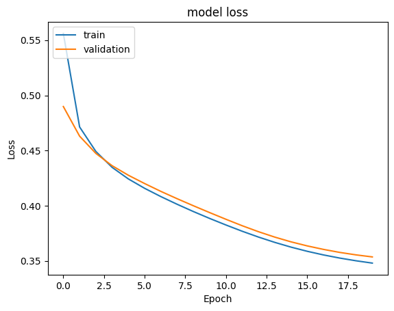

```python
#Plotting Train Loss vs Validation Loss
plt.plot(fitted_model_01.history['loss'])
plt.plot(fitted_model_01.history['val_loss'])
plt.title('model loss')
plt.ylabel('Loss')
plt.xlabel('Epoch')
plt.legend(['train', 'validation'], loc='upper left')
plt.show()
```

**Model Loss Observations**  
**Observations from the Provided Loss Curve**  
**Convergence Trend**

- Both the training and validation losses are steadily decreasing, which suggests that the model is learning effectively without signs of major overfitting.
- The trend shows a smooth decrease in loss over the epochs, indicating that the model is optimizing well.

No Overfitting:

- The training and validation losses are closely aligned throughout the training process. This suggests that the model generalizes well to unseen data (validation set) and is not overfitting.
- Overfitting would typically show a divergence where the training loss continues to decrease, but the validation loss starts to increase. This is not evident in the current plot.

**Saturation Point**

- While the losses are still decreasing, the rate of decrease is slowing down as training progresses. This could indicate that the model is nearing a point of diminishing returns in terms of further loss reduction.

**Possible Further Training**

- Since there is no significant gap between the training and validation losses and both are still decreasing, it might be beneficial to continue training for a few more epochs to see if the loss can be reduced further. However, you should monitor for any signs of overfitting.

**Learning Rate and Optimization**

- The smooth decrease in loss indicates that the learning rate is likely set appropriately for the optimizer (SGD). If the loss had been oscillating or diverging, it might have suggested a need to adjust the learning rate.

**Recommendations**